# Roulette Simulation

Sarah Torrence

September 08, 2020

# 1 Introduction

If you have any interest in gambling you would be familiar with the game Roulette. Further, if you have played Roulette you might be familiar with the classic strategy called the Martingale strategy. Using some simple math and logic it seems that the Martingale strategy leaves the player with positive earnings, but is that really true? We know gambling games are typically set up so the house wins in the long run making the Martingale strategy seem too good to be true. Using simulation, I have set out to test the Martingale strategy to determine whether it really works.

## 1.1 Background

[figure not shown]

In the American version of Roulette, the wheel consists of 38 evenly sized pockets 18 of which are red, 18 black and 2 green as shown in the above image. These pockets are also numbered up to 36 including 0 and 00. In the game, a pocket is randomly selected. Before selection, gamblers may wage on the outcome in several different ways including selecting a specific number or color trying to predict the outcome.

For our purposes, we will ignore the numbers and only use the colors of red, black and green. For each $1 wager a gambler places on a specific color, they will win $1 if the color chosen is the outcome of the game. For example, if the gambler bets $1 on red and a red pocket is in fact randomly selected, the gambler would be given $2 (the original $1 wager and the additional $1 of winnings). If red is not selected, the gambler would be at a loss of $1 which was their original wager.

Using the Martingale strategy, a gambler would chose a color, red or black, and stick with this color for each round. Their starting wager would be $1. If the outcome is not the color of their choice, they would double their wager to $2 and continue doubling their wager until they are successful. The round after their chosen color is selected they will go back to their original wager of $1.

[figure not shown]

Consider the below sequence of spins with the following outcomes in which the gambler chose to wager money on Red as the outcome.

| Play | Wager | Outcome | Earnings |
| --- | --- | --- | --- |
| 1 | 1 | Black | -1 |
| 2 | 2 | Black | -3 |
| 3 | 4 | Red | +1 |

| Play | Wager | Outcome | Earnings |
| --- | --- | --- | --- |
| 1 | 1 | Black | -1 |
| 2 | 2 | Black | -3 |
| 3 | 4 | Black | -7 |
| 4 | 8 | Red | +1 |

It appears that using the Martingale strategy, the gambler always comes out ahead with earnings of $1. Does this still hold true over many iterations?

# 2 Methods

Here I will simulate the Martingale strategy to find the average earnings of a gambler assuming the gambler wagers on the spin selecting a red pocket with a probability of 18/38. The parameters are the budget (amount of money the gambler can spend) (**B**), the budget threshold for successfully stopping (**W**), the maximum number of plays allowed (**L**) and the casino’s wager limit (**M**). Using these parameters, I conduct a series of single spins in which the previous result (win/loss) is used to determine whether the wager in the next spin is $1 (if the previous was spin was red) or double the previous wager (if the spin was black or green). This series of spins continues until the gambler runs out of money (he/she has none of their original budget remaining), hits the maximum number of plays, or reaches the threshold for successfully stopping.

Below is a table showing the parameters used and their starting values for purposes of this simulaion:

| Parameter | Description | Starting value |
| --- | --- | --- |
| **B** | Starting budget | $200 |
| **W** | Winnings threshold for stopping | $300 (Starting budget + $100 winnings) |
| **L** | Time threshold for stopping | 1000 plays |
| **M** | Casino’s maximum wager | $100 |

```r
#' A single play of the Martingale strategy
#'
#' Takes a state list, spins the roulette wheel, returns the state list with updated values (for example, budget, plays, etc)
#' @param state A list with the following entries:
#'   B              number, the budget
#'   W              number, the budget threshold for successfully stopping
#'   L              number, the maximum number of plays
#'   M              number, the casino wager limit
#'   plays          integer, the number of plays executed
#'   previous_wager number, the wager in the previous play (0 at first play)
#'   previous_win   TRUE/FALSE, indicator if the previous play was a win (TRUE at first play)
#' @return The updated state list
one_play <- function(state){

    # Wager
    proposed_wager <- ifelse(state$previous_win, 1, 2*state$previous_wager)
    wager <- min(proposed_wager, state$M, state$B)

    # Spin of the wheel
    red <- rbinom(1,1,18/38)

    # Update state
    state$plays <- state$plays + 1
    state$previous_wager <- wager
    if(red){
      # WIN
      state$B <- state$B + wager
      state$previous_win <- TRUE
    }else{
      # LOSE
      state$B <- state$B - wager
      state$previous_win <- FALSE
    }
  state
}


#' Stopping rule
#'
#' Takes the state list and determines if the gambler has to stop
#' @param state A list.  See one_play
#' @return TRUE/FALSE
stop_play <- function(state){
  if(state$B <= 0) return(TRUE)
  if(state$plays >= state$L) return(TRUE)
  if(state$B >= state$W) return(TRUE)
  FALSE
}


#' Play roulette to either bankruptcy, success, or play limits
#'
#' @param B number, the starting budget
#' @param W number, the budget threshold for successfully stopping
#' @param L number, the maximum number of plays
#' @param M number, the casino wager limit
#' @return A vector of budget values calculated after each play.
one_series <- function(
    B = 200
  , W = 300
  , L = 1000
  , M = 100
){

  # initial state
  state <- list(
    B = B
  , W = W
  , L = L
  , M = M
  , plays = 0
  , previous_wager = 0
  , previous_win = TRUE
  )

  # vector to store budget over series of plays
  budget <- rep(NA, L)

 # For loop of plays
  for(i in 1:L){
    new_state <- state %>% one_play
    budget[i] <- new_state$B
    if(new_state %>% stop_play){
      num_plays <- new_state$plays
      return(data.frame(budget[1:i],num_plays))
    }
    state <- new_state
  }
  budget
}

# helper function
get_last <- function(x) tail(x,n=1)
```

I ran the simulation once to replicate the process of one player using this strategy with the above starting values and graphed the relationship between the gamblers earnings and the number of rounds of Roulette they had played.

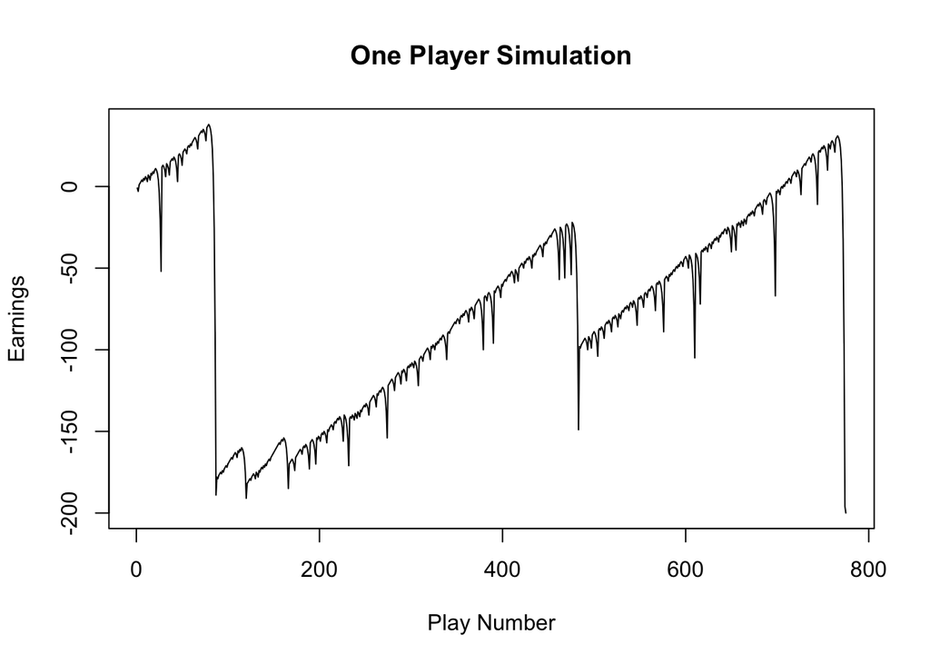

```r
#Simulating one play
first_play <- one_series(B = 200, W = 300, L = 1000, M = 100)

#Plotting the earnings based on play number
plot(x=c(1:length(first_play[,1])),y=first_play[,1]-200, type="l",xlab = "Play Number", ylab = "Earnings",main="One Player Simulation")
```

Here is the graph of a second player’s simulation again with the same starting values as above.

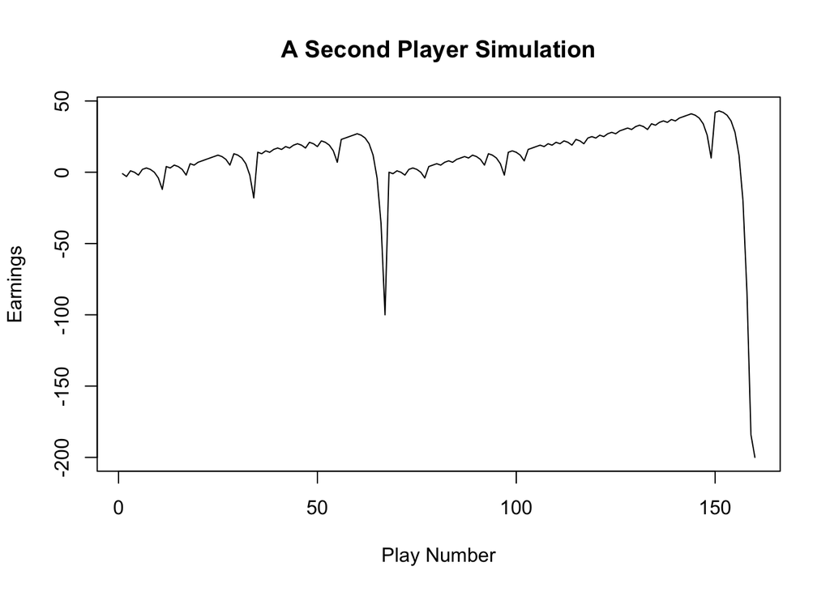

```r
#Simulating a second play
second_play <- one_series(B = 200, W = 300, L = 1000, M = 100)

#Plotting the earnings based on play number
plot(x=c(1:length(second_play[,1])),y=second_play[,1]-200, type="l",xlab = "Play Number", ylab = "Earnings",main="A Second Player Simulation")
```